# wk10d1 - homework

```r
library(tidyverse)
```

# MVP

```r
project <- read_csv("data/project_management.csv")
```

```r
glimpse(project)
```

```
Rows: 50
Columns: 3
$ ...1             <dbl> 1, 2, 3, 4, 5, 6, 7, 8, 9, 10, 11, 1…
$ estimated_length <dbl> 12, 16, 16, 18, 22, 19, 18, 18, 18, …
$ actual_length    <dbl> 17, 22, 23, 25, 39, 24, 24, 21, 23, …
```

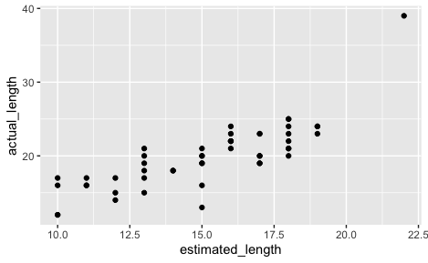

```r
# plot estimate v actual lengths
project %>%
  ggplot() +
  geom_point(aes(estimated_length, actual_length))
```

The estimates look to be binned, and contain a range of actual values per estimate.

Overall, looks to be a positive correlation

```r
# calculate correlation coefficient
project %>%
  summarise(corr = cor(estimated_length, actual_length))
```

| corr |
| --- |
| 0.8046597 |

With a Pearson coefficient of correlation of 0.80, we can say these variables are very strongly positively correlated.

```r
# generate a simple linear regression model
# remember formula order = outcome ~ predictor
model <- lm(formula = actual_length ~ estimated_length, data = project)
```

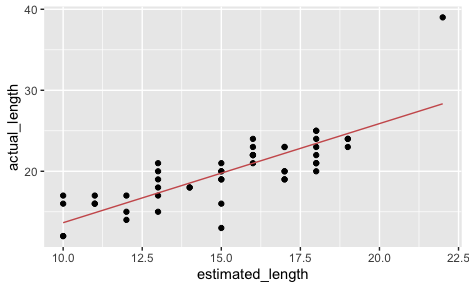

```r
# plot the line of best fit from the model
project_plot <- project %>%
  modelr::add_predictions(model) %>%
  modelr::add_residuals(model) %>%
  ggplot(aes(x = estimated_length, y = actual_length)) +
  geom_point() +
  geom_line(aes(y = pred), col = "indianred")

project_plot
```

```r
model
```

```
Call:
lm(formula = actual_length ~ estimated_length, data = project)

Coefficients:
     (Intercept)  estimated_length
           1.416             1.223
```

```r
summary(model)
```

```
Call:
lm(formula = actual_length ~ estimated_length, data = project)

Residuals:
    Min      1Q  Median      3Q     Max
-6.7687 -1.6513  0.1195  1.1252 10.6669

Coefficients:
                 Estimate Std. Error t value Pr(>|t|)
(Intercept)        1.4164     2.0069   0.706    0.484
estimated_length   1.2235     0.1303   9.389 1.91e-12 ***
---
Signif. codes:  0 ‘***’ 0.001 ‘**’ 0.01 ‘*’ 0.05 ‘.’ 0.1 ‘ ’ 1

Residual standard error: 2.606 on 48 degrees of freedom
Multiple R-squared:  0.6475,    Adjusted R-squared:  0.6401
F-statistic: 88.16 on 1 and 48 DF,  p-value: 1.911e-12
```

```r
broom::glance(model)
```

| r.squared | adj.r.squared | sigma | statistic | p.value | df | logLik | AIC | BIC | deviance | df.residual | nobs |
| --- | --- | --- | --- | --- | --- | --- | --- | --- | --- | --- | --- |
| 0.6474772 | 0.640133 | 2.606163 | 88.16142 | 1.911284e-12 | 1 | -117.8203 | 241.6407 | 247.3767 | 326.0201 | 48 | 50 |

**What does the regression coefficient of our model tell us?**

The model fits a best fit line where: actual_length = 1.2 * estimated_length + 1.4

So the estimate is not quite 1:1 with the actual (that would be actual_length = estimated_length with slope = 1, intercept = 0), but the slope and intercept are quite small so it’s also not far off (numerically) as an estimate.

R^2 is 0.647 - this tells us that in our model, 65% of the variation in actual_length can be explained by the variation in estimated_length, so the model is a good fit (but there is room for improvement - and it would be better if the estimate itself was a better predictor of the actual length).

**Is the relationship statistically significant?**

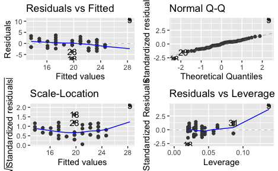

```r
library(ggfortify)
autoplot(model)
```

The diagnostic plots indicate that a linear model is a good choice - the Residuals v Fitted line is roughly horizontal and around 0, and most of the points map onto the QQ line - there’s just one data point that is high at the highest x value, and this affects the line at the end (far right) for both top-row plots; and there may also be a deviating point at the lower quantile.

With the linear model, the p-value of the regression coefficient is 1.911e-12, which is very small (p<0.00..001), which signifies that the relationship is highly statistically significant.

# Extension

## Leverage

- high (magnitude) data points can influence the line of best fit model a lot more than lower magnitude values (e.g. changing a high value off to the top right in a scatter plot changes the line more than if a middle value were tweaked).
- the residuals v leverage plot (from autoplot or base::plot, see below) helps us understand:
  - 1.Heteroskedasticity and non-linearity: a change in noise level across the x axis. For homoskedasticity (no change in noise across the data range, which is what we want) “the spread of standardized residuals shouldn’t change as a function of leverage”
  - 2. Whether any points are overly influential, using Cook’s distance (the dotted line in the plot) - points outside Cook’s distance are highly influential for the model, deleting them would change the model a lot. If these are outliers, we might want to remove them.

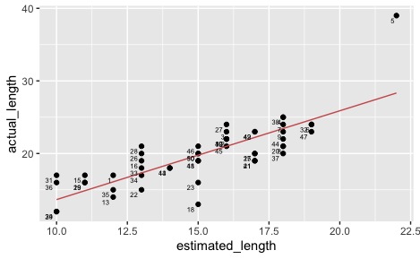

```r
# label the data points in the model plot
# visually identify any potential outliers
project_plot +
  geom_text(aes(label = 1:nrow(project)), hjust = 1.5, vjust = 1.5, size = 2)
```

From this, I suspect **data point 5** is an influential outlier. **data point 18** looks a little low for the general trend, so may be an outlier, but it likely doesn’t have high leverage (sits in the middle of values) so I would expect it is a non-influential outlier.

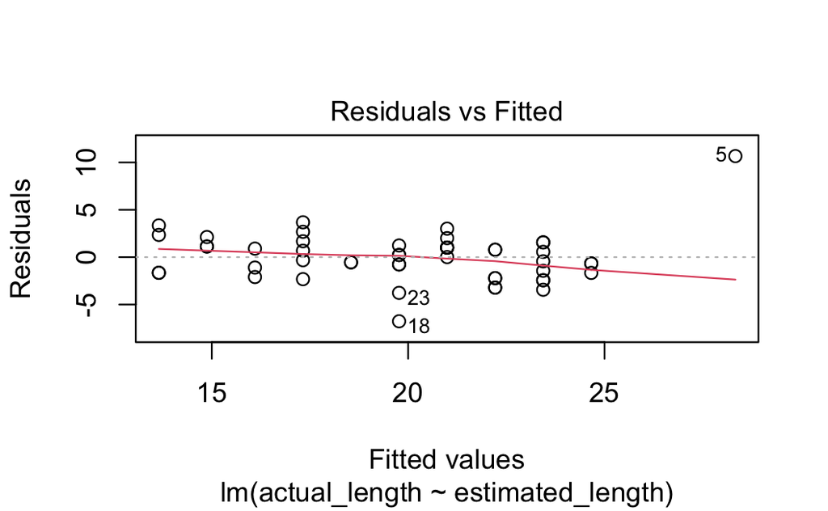

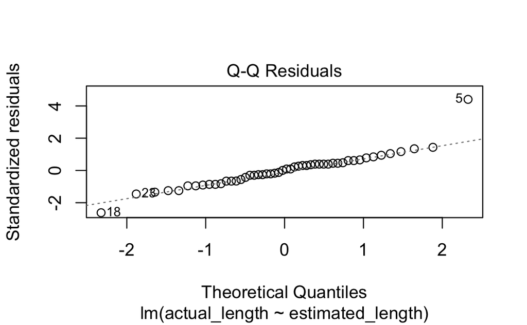

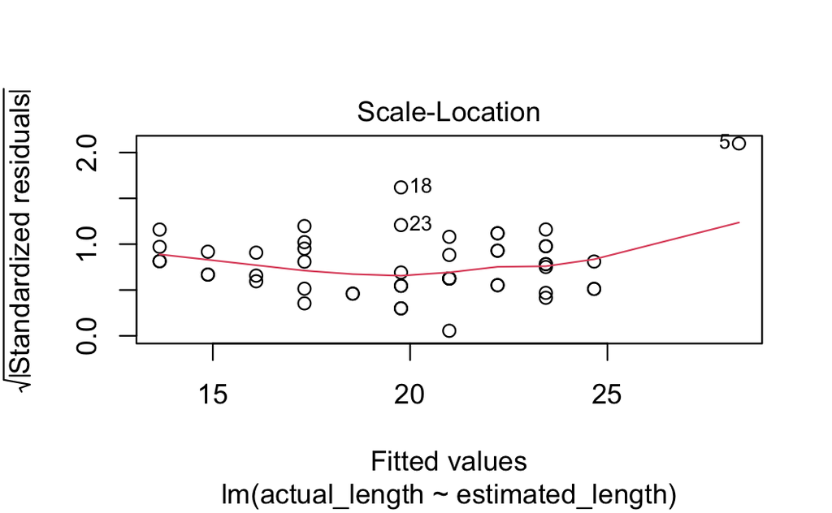

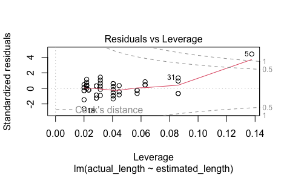

```r
plot(model)
```

Here, the spread of the values does not seem to differ across the majority of the range, so I think this tells us the data is homoskedastic (good!). However **data point 5 sits outside Cook’s distance line**, and is pulling the leverage line upwards, indicating it may be a highly influential outlier and we may want to consider removing it (if this makes sense) to produce a better model for the other values.

**Data point 18** is lower than the fitted line for leverage ~ residuals, has low leverage and is not outside Cook’s distance, so it may be a non-influential outlier.

### from answers:

you can directly plot cook’s distance for each point:

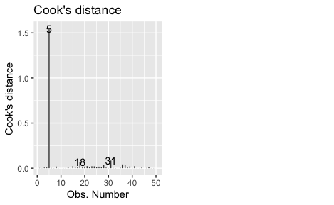

```r
autoplot(model, which = 4)
```

**Interpret:**

Cook’s distance for 5 looks substantially greater for others - an outlier, maybe return to raw data and consider how this estimate was made

points 18 and 31 are higher but not very different from the rest - not outliers.

## Remodel after removing non-influential outlier (18)

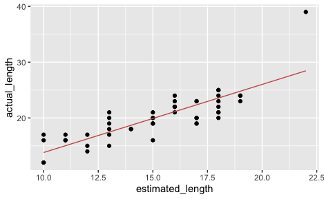

```r
# create a new df with removed row
project_rm18 <- project %>%
  filter(row_number() != 18)

# generate new model
model_rm18 <- lm(formula = actual_length ~ estimated_length, data = project_rm18)

# plot this
project_rm18 %>%
  modelr::add_predictions(model_rm18) %>%
  modelr::add_residuals(model_rm18) %>%
  ggplot(aes(x = estimated_length, y = actual_length)) +
  geom_point() +
  geom_line(aes(y = pred), col = "indianred")
```

The line of best fit still looks like it models the data trend well.

```r
model
```

```
Call:
lm(formula = actual_length ~ estimated_length, data = project)

Coefficients:
     (Intercept)  estimated_length
           1.416             1.223
```

```r
model_rm18
```

```
Call:
lm(formula = actual_length ~ estimated_length, data = project_rm18)

Coefficients:
     (Intercept)  estimated_length
           1.591             1.221
```

```r
summary(model_rm18)
```

```
Call:
lm(formula = actual_length ~ estimated_length, data = project_rm18)

Residuals:
    Min      1Q  Median      3Q     Max
-3.9072 -1.7915  0.0928  0.9771 10.5453

Coefficients:
                 Estimate Std. Error t value Pr(>|t|)
(Intercept)        1.5911     1.8782   0.847    0.401
estimated_length   1.2211     0.1219  10.019 3.02e-13 ***
---
Signif. codes:  0 ‘***’ 0.001 ‘**’ 0.01 ‘*’ 0.05 ‘.’ 0.1 ‘ ’ 1

Residual standard error: 2.438 on 47 degrees of freedom
Multiple R-squared:  0.6811,    Adjusted R-squared:  0.6743
F-statistic: 100.4 on 1 and 47 DF,  p-value: 3.015e-13
```

```r
# broom::glance(model_rm18)
```

In the original model, the slope was 1.223 and intercept 1.416.

In the model from the df dropping row 18, the regression coefficient (slope) = 1.221, and the intercept = 1.591. Removing this row has not changed the model parameters much - so this supports the prediction that it is not an influential outlier.

R^2 has changed to 0.68, so this model is now a slightly better fit (explains 68% variation rather than 65%) and the p-value is still very low so this is a significant relationship.

## Remodel after removing influential outlier (5)

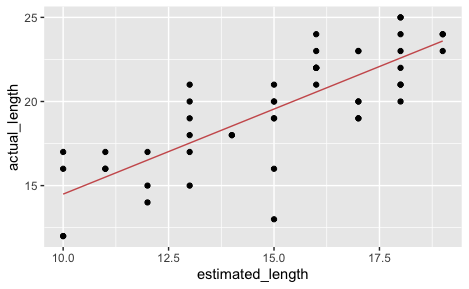

```r
project_rm5 <- project %>%
  filter(row_number() != 5)

model_rm5 <- lm(formula = actual_length ~ estimated_length, data = project_rm5)

# plot this
project_rm5 %>%
  modelr::add_predictions(model_rm5) %>%
  modelr::add_residuals(model_rm5) %>%
  ggplot(aes(x = estimated_length, y = actual_length)) +
  geom_point() +
  geom_line(aes(y = pred), col = "indianred")
```

Removing point 5 shortens our x-range, our fitted line still looks to fit the data

```r
model
```

```
Call:
lm(formula = actual_length ~ estimated_length, data = project)

Coefficients:
     (Intercept)  estimated_length
           1.416             1.223
```

```r
model_rm5
```

```
Call:
lm(formula = actual_length ~ estimated_length, data = project_rm5)

Coefficients:
     (Intercept)  estimated_length
           4.381             1.011
```

```r
summary(model_rm5)
```

```
Call:
lm(formula = actual_length ~ estimated_length, data = project_rm5)

Residuals:
    Min      1Q  Median      3Q     Max
-6.5510 -1.5737  0.4376  1.4376  3.4717

Coefficients:
                 Estimate Std. Error t value Pr(>|t|)
(Intercept)        4.3806     1.6504   2.654   0.0108 *
estimated_length   1.0114     0.1083   9.338 2.79e-12 ***
---
Signif. codes:  0 ‘***’ 0.001 ‘**’ 0.01 ‘*’ 0.05 ‘.’ 0.1 ‘ ’ 1

Residual standard error: 2.032 on 47 degrees of freedom
Multiple R-squared:  0.6498,    Adjusted R-squared:  0.6423
F-statistic: 87.19 on 1 and 47 DF,  p-value: 2.787e-12
```

```r
# broom::glance(model_rm5)
```

Removing data point 5 shifts the slope from 1.2 to 1.0, and shifts the intercept from 1.4 to 4.4, so has a larger affect on our model.

R^2 has not changed (still 65%) so this model is just as good a fit as the original model,and the p-value is still very low so this is a significant relationship.

Therefore, while this outlier seems to have been influential, it hasn’t improved or worsened the goodness of fit of our model (from the residuals) but has changed (potentially improved) the function for explaining the relationship between estimated and actual length.

### Homework review: Interpreting regression diagnostics

#### assumptions of linear regression

1. that the relationship is actually linear
2. errors (residuals) should be normally distributed
3. errors are homoskedastic (size of error has constant variance across whole range of fitted values) (4. x is measured without error)

#### testing assumptions using autoplot

- **Residuals v fitted** - you should see scattergun of points, no pattern. If pattern, the model is not linear.
- **Normal Q-Q** - the normal distribution of the residuals. should be linear to indicate that the frequency distribution of the residuals is a normal bell curve (small/0 residuals are most frequent, middle of bell curve peak, large +- residuals are few)
- **Scale - Location** - check for homoskedasticity. If there is a wedge/triangle or other shape where the variance of the standardised residuals differs across the x axis, this indicates there is NOT constant variance (heteroskedasticity). Your model is working less well at places of high variance – you may need to add in more predictors to reduce variance, or there may be clusters/groups in your data that you need to slice by. i.e. work on better modelling your data.
- **Residuals v Leverage** - line of best fit pivots around the centroid, points further from the centre can pivot the slope of the line, they have greater leverage than points in the middle (on the fulcrum). plotting for distance from centroid (leverage) v residuals shows if there is a high error point far from the centroid that may be exerting too much influence on the shape of the line (see Cook’s distance): anything close to Cook’s distance lines, take a look at it (the raw data, how the raw data was made, etc)… see notebook for drawings. Leverage is more about effect on slope not intercept, Cook’s distance line is asymptotic at leverage 0

Can do the histogram manually

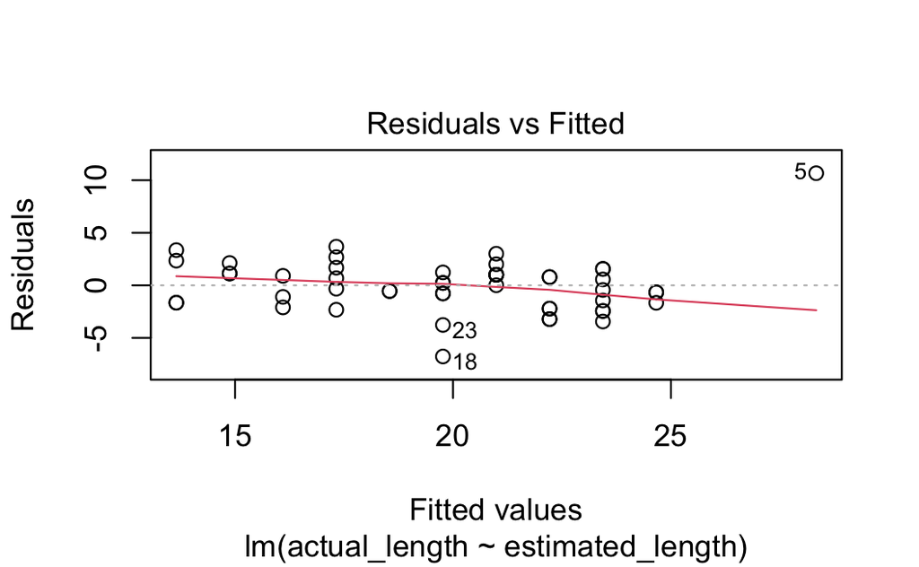

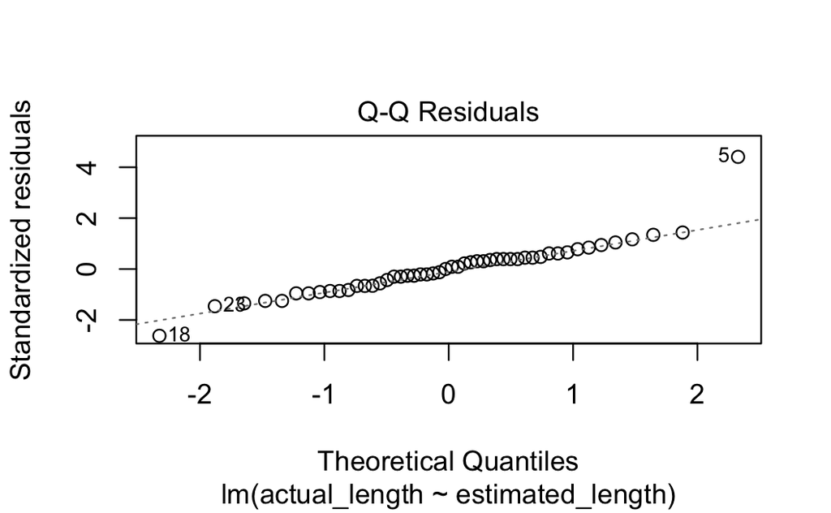

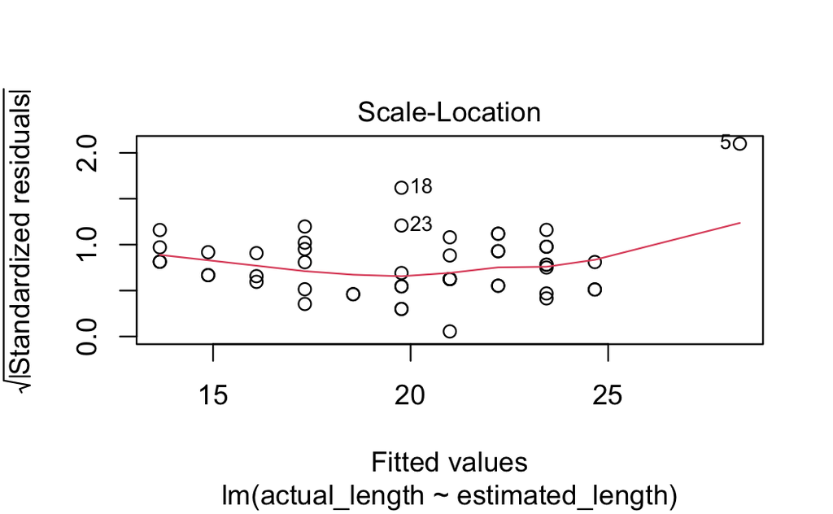

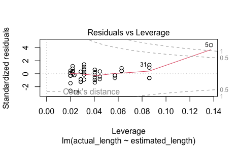

```r
#par(mfrow = c(2,3)) # brings plots together in a panel
# 2 rows by 3 cols
plot(model) # as above
```

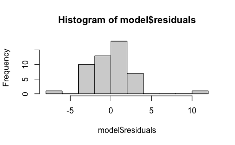

```r
hist(model$residuals) # adds a histogram for
```

```r
# frequency of residuals by their size
```

```r
mean(project$estimated_length)
```

```
[1] 15.14
```

```r
mean(project$actual_length)
```

```
[1] 19.94
```